# ERCC fractions and cell number correspondence

Jason T. Serviss

2018-01-26

## Introduction

Here we wanted to understand how the fraction of ERCC counts, and the number of cells derived from this metric, corresponds to the actual number of cells. Therefore, sorted singlets and multiplets, where the cell numbers for both were known, were used to analyze this. In addition, we wanted to get a feeling for how strongly each cell type in the dataset contributes to an individual multiplet when it is present in that multiplet.

```r
packages <- c(
    "sp.scRNAseq",
    "sp.scRNAseqData",
    "sp.scRNAseqTesting",
    "printr",
    "ggthemes",
    "tidyverse"
)
purrr::walk(packages, library, character.only = TRUE)
rm(packages)
```

Run method for real data.

```r
sng <- str_detect(colnames(countsSorted2), "^s")

#create counts objects
cObjSng <- spCounts(countsSorted2[, sng], countsSortedERCC2[, sng])
cObjMul <- spCounts(countsSorted2[, !sng], countsSortedERCC2[, !sng])

#spUnsupervised
uObj <- spUnsupervised(cObjSng)

#rename classes
positions <- str_extract(colnames(getData(cObjSng, "counts")), "...$")
newClass <- case_when(
  positions == "E03" ~ "A375", #what is this? sorting issue?
  positions %in% paste0(sort(rep(LETTERS[1:8], 4)), c("01", "02", "03", "04")) ~ "HOS",
  positions %in% paste0(sort(rep(LETTERS[1:8], 4)), c("05", "06", "07", "08")) ~ "HCT116",
  positions %in% paste0(sort(rep(LETTERS[1:8], 4)), c("09", "10", "11", "12")) ~ "A375",
  TRUE ~ "error"
)
corresp <- getData(uObj, "classification") %>%
  tibble(oldClass = ., newClass = newClass) %>%
  distinct()

classification(uObj) <- newClass

gm <- getData(uObj, "groupMeans")
colnames(gm) <- pull(corresp, newClass)[match(colnames(gm), pull(corresp, oldClass))]
groupMeans(uObj) <- gm

tm <- getData(uObj, "tsneMeans")
tm$classification <- pull(corresp, newClass)[match(tm$classification, pull(corresp, oldClass))]
tsneMeans(uObj) <- tm
```

## Relationship between fraction of ERCC reads and cell number.

The number of cells is calculated using the ERCC fractions according to the following:

frac.ercc = colSums(counts.ercc) / (colSums(counts.ercc) + colSums(counts))  
cellNumberMin = frac.ercc / (quantile(frac.ercc)[4] / frac.ercc)  
cellNumberMedian = frac.ercc / (median(frac.ercc) / frac.ercc)  
cellNumberMax = frac.ercc / (quantile(frac.ercc)[2] / frac.ercc)

Although cellNumberMedian is assumed to give the most accurate result, it can occasionally be useful to estimate an upper and lower bound for the number of cells and, therefore, the other two calculations are routinely performed.

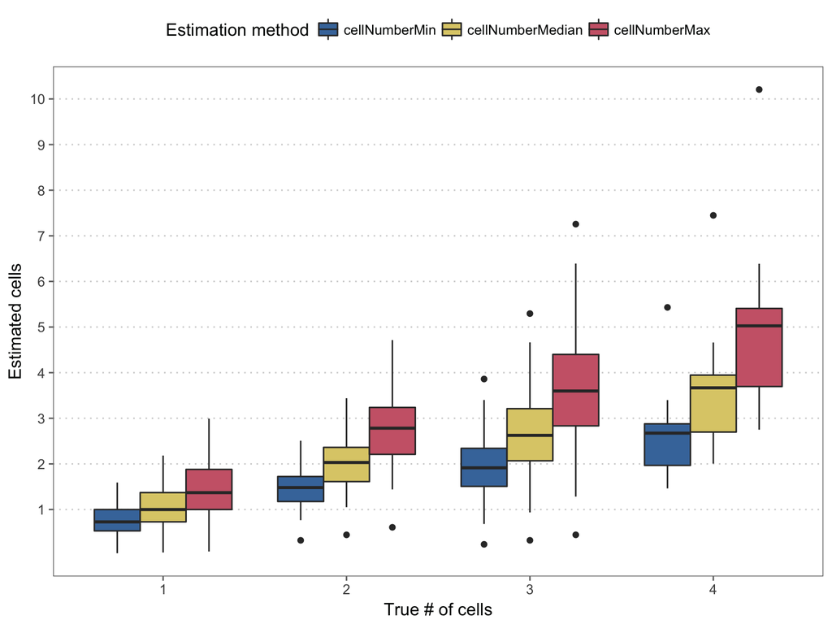

```r
data <- estimateCells(cObjSng, cObjMul) %>%
  gather(`Estimation method`, `Estimated cells`, -sampleName, -sampleType, -frac.ercc) %>%
  mutate(`True # of cells` = case_when(
    str_detect(sampleName, "^s") ~ 1L,
    str_extract(sampleName, "..$") %in% c("01", "02", "03", "04") ~ 2L,
    str_extract(sampleName, "..$") %in% c("05", "06", "07", "08") ~ 3L,
    str_extract(sampleName, "..$") %in% c("09", "10", "11", "12") ~ 4L
  ))

pFun <- function() {
  data %>%
    mutate(diff = `Estimated cells` - `True # of cells`) %>%
    filter(`Estimation method` == "cellNumberMedian") %>%
    group_by(`True # of cells`) %>%
    summarize(mDiff = mean(diff)) %>%
    pull(mDiff)
}

data %>%
  mutate(`True # of cells` = parse_factor(
    `True # of cells`,
    levels = sort(unique(`True # of cells`))
  )) %>%
  mutate(`Estimation method` = parse_factor(
    `Estimation method`,
    levels = c("cellNumberMin", "cellNumberMedian", "cellNumberMax")
  )) %>%
  mutate(sampleType = parse_factor(sampleType, unique(sampleType))) %>%
  ggplot() +
  geom_hline(yintercept = 1:10, lty = 3, colour = "lightgrey") +
  geom_boxplot(aes(x = `True # of cells`, y = `Estimated cells`, fill = `Estimation method`)) +
  scale_y_continuous(breaks = 1:10) +
  theme_few() +
  scale_fill_ptol() +
  theme(legend.position = "top")
```

### Conclusion

The results indicate that the median value for cellNumberMedian calculation corresponds well with the true value in singlets and duplicates. In triplicates and quadruplicates, the cellNumberMedian calculation somewhat underestimates the true value but still provides the most accurate method of calculation. In addition, the overall results are quite variable and this variation increases as the number of cells increases. The maximum absolute differences of the estimation from the ground truth are are 1.2, 1.6, 2.7, and 3.5 cells for singlets, doublets, triplets, and quadruplicates, respectivley.

## Cell type contribution to multiplets

Below we investigate the fraction of ercc reads per cell type and, thus, give an approximate indication of their contribution to multiplets that they are included in.

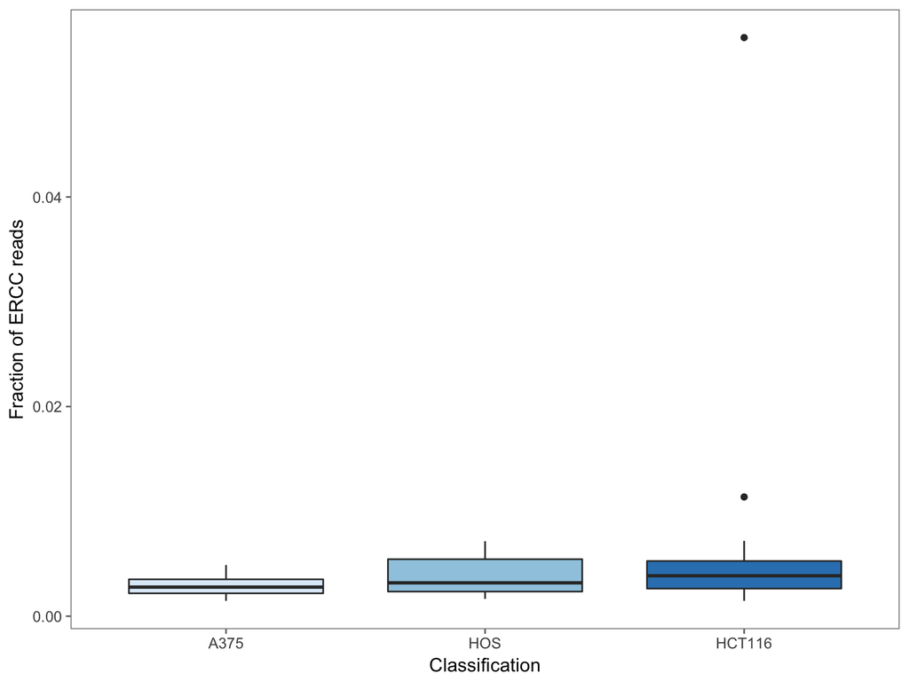

```r
getData(uObj, "tsne") %>%
  as.data.frame() %>%
  rownames_to_column(var = "sampleName") %>%
  as_tibble() %>%
  select(-V1, -V2) %>%
  add_column(classification = getData(uObj, "classification")) %>%
  left_join(estimateCells(cObjSng, cObjMul), by = "sampleName") %>%
  mutate(classification = parse_factor(classification, levels = c("A375", "HOS", "HCT116"))) %>%
  ggplot() +
  geom_boxplot(aes(x = classification, y = frac.ercc, fill = classification)) +
  theme_few() +
  scale_fill_brewer() +
  guides(fill = FALSE) +
  labs(
    x = "Classification",
    y = "Fraction of ERCC reads"
  )
```

### Conclusion

The results indicate that A375 cells have the lowest median fraction of ERCC reads followed by HOS and HCT116 cells. We would therefore expect the amount of contribution of these cell types to a multiplet to be in the reverse order, i.e. HCT116, HOS, A375.